# Lecture 6.3: Boosting and Stacking

ADS/STAT 5526 Statistical Learning (part 2)

Dr. Christopher Grubb

## Boosting and stacking for tree-based methods

**From averaging trees to learning from their mistakes**

- Boosting: build a sequence of trees that sequentially improves one predictive model.
- Stacking: combine predictions from separately trained models, using information about where each models perform best.

## Where we left off: bagging and random forests

- A deep decision tree can change substantially when its training data change.
- Bagging averages trees trained on bootstrap samples.
- Random forests also randomize candidate predictors.
- Averaging is most effective when individual errors are not too correlated.

## Three ways to combine predictive models

| Method | How components are trained | What is learned at the end? |
| --- | --- | --- |
| Bagging / random forest | Largely independently, on randomized data or splits | An average or vote |
| Boosting | Sequentially, responding to the current model’s errors | An additive prediction rule |
| Stacking | Base learners separately; combiner trained on their predictions | A learned combination rule |

## The core idea of a boosted tree model

Start with a simple prediction. Add a small tree, then another:

$$F_M(x)=F_0(x)+\eta\sum_{m=1}^{M}h_m(x).$$

- Each tree ($h_m$) contributes a correction to the **current ensemble**.
- The learning rate ($\eta$) controls the size of each correction.
- The final predictor is a sum, not a vote among interchangeable trees.

## What does a shallow tree add?

A regression tree partitions predictor space into leaves and predicts a constant in each leaf.

$$h_m(x)=\sum_{j=1}^{J_m}\gamma_{jm}\,\mathbf{1}\{x\in R_{jm}\}.$$

- Regions can target *where* the current model is wrong.
- Leaf values determine *how much* to correct there.
- A sum of simple trees can represent a rich function.

## Squared-error boosting: the clearest case

Use half the squared-error loss:

$$L(y,F(x))=\tfrac{1}{2}\bigl(y-F(x)\bigr)^2.$$

At each stage:

1. Compute residuals from the current ensemble.
2. Fit a small regression tree to those residuals.
3. Add a scaled version of that tree’s predictions.

## Visual: first tree corrects the mean

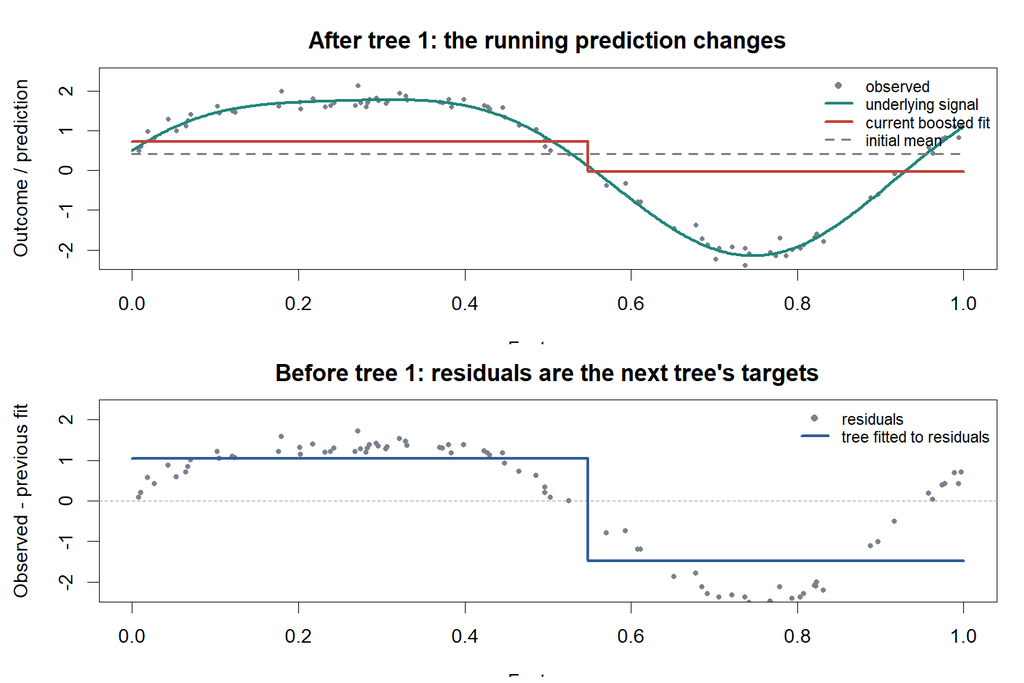

## Visual: five trees, five small corrections

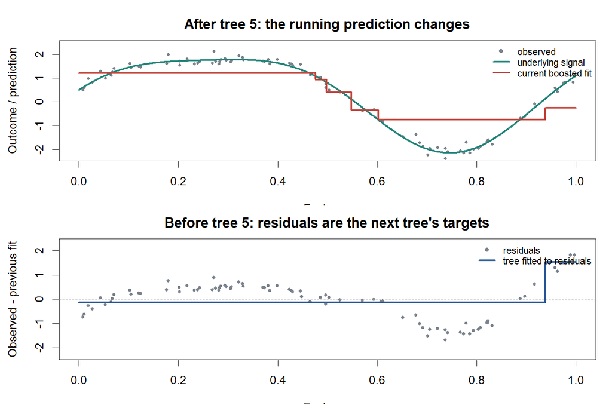

## Visual: many stages, then stop and validate

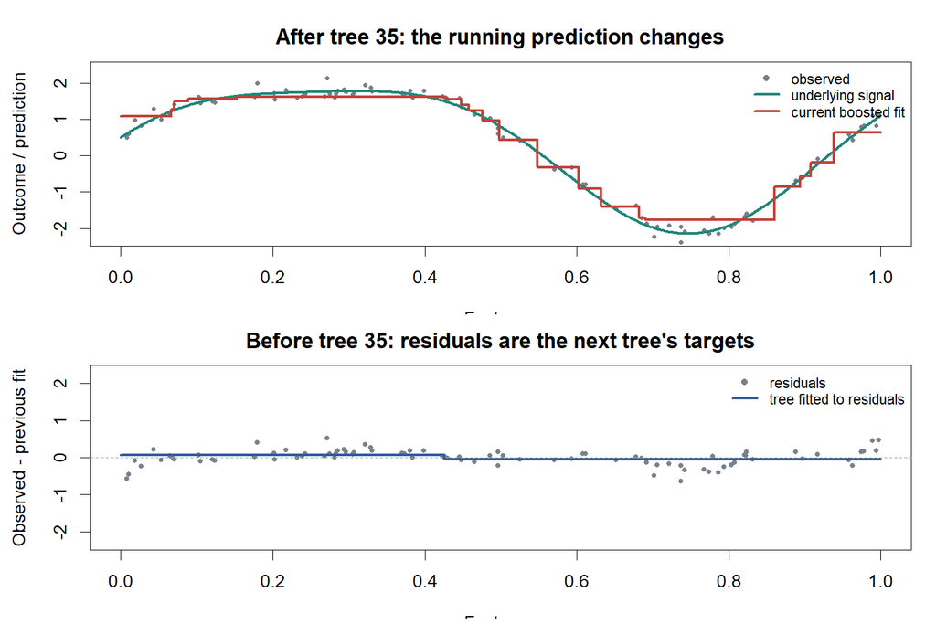

## Learning rate: take smaller steps

$$F_m(x)=F_{m-1}(x)+\eta h_m(x),\qquad 0<\eta\leq 1.$$

- Smaller steps typically require more stages.
- Slower fitting can improve validation performance, but not automatically.
- The learning rate, number of trees, and tree depth should be considered **together**.

## From residuals to gradients

For any differentiable loss, ask which change in the current prediction would reduce loss fastest.

$$r_{im}=-\left.\frac{\partial L(y_i,F(x_i))}{\partial F(x_i)}\right|_{F=F_{m-1}}.$$

- These **negative gradients** are called pseudo-residuals.
- Fit a tree to approximate them across predictor space.
- The loss determines what the model treats as a mistake.

## Why squared-error gradients are residuals

With half squared error:

$$\frac{\partial L(y,F)}{\partial F}=\frac{\partial L(\tfrac{1}{2}\bigl(y-F(x)\bigr)^2)}{\partial F}=F-y,$$

so the negative gradient is

$$-\frac{\partial L(y,F)}{\partial F}=y-F.$$

**Ordinary residuals are exactly the direction of steepest improvement for this loss.**

## Binary classification: improve probability estimates

Let the model score be converted to a probability:

$$p(x)=\frac{1}{1+e^{-F(x)}}.$$

For binary cross-entropy,

$$L(y,F)=-y\log p-(1-y)\log(1-p),\qquad y\in\{0,1\}.$$

The negative gradient with respect to the score is

$$y-p.$$

## Choosing the size of each leaf’s correction

A tree first chooses regions. Leaf contributions can then be chosen to reduce the original loss:

$$\gamma_{jm}=\underset{\gamma}{\operatorname{argmin}}\sum_{i:x_i\in R_{jm}}L\!\left(y_i,F_{m-1}(x_i)+\gamma\right).$$

The ensemble adds a learning-rate-scaled version of those leaf contributions.

## Generic gradient-boosted trees

1. Start with a constant prediction that minimizes the training loss.
2. At each stage, calculate negative gradients at current predictions.
3. Fit a small tree to those gradient targets.
4. Find useful leaf corrections; scale and add them to the model.
5. Repeat until a chosen stopping point.

## Tree size controls interaction complexity

- A stump makes one split; its contribution depends on one predictor.
- Deeper trees can create regions defined by multiple split conditions.
- Deeper trees can model interactions within a stage, but add flexibility.
- More stages and greater depth both increase model capacity.

## How many stages? Watch validation loss

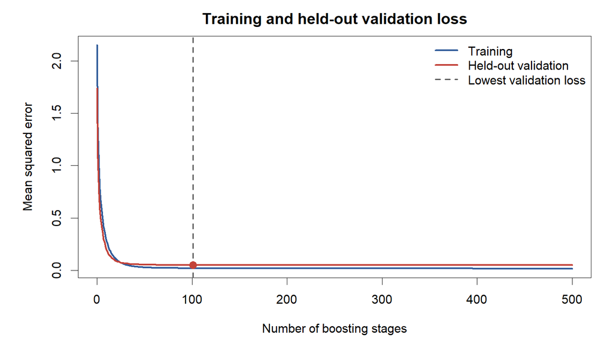

Training loss can keep falling after validation loss reaches its minimum. Select the stopping point without inspecting the final test set.

## Stochastic gradient boosting

At a stage, fit the next tree using a random subset of training rows; some implementations also subsample predictors.

- Adds randomness to an otherwise sequential process.
- Can reduce computation and sometimes improve generalization.
- The next stage still depends on the current ensemble.

**Row subsampling does not turn boosting into bagging.**

## Where boosted trees can struggle

- Noisy labels or influential observations can steer corrections.
- Too much depth, too many stages, or aggressive tuning can overfit.
- Small datasets can make validation estimates unstable.
- Predictions beyond the training feature range may extrapolate poorly.

**The loss and validation design determine what “better” means.**

## AdaBoost: a related path to boosting

For binary labels, AdaBoost repeatedly fits weak classifiers while changing observation weights.

- Misclassified observations receive more emphasis in later rounds.
- Each weak classifier receives a weight in the final score.
- The final class is determined by the sign of the weighted sum.

**Different mechanism from fitting trees to loss gradients.**

## AdaBoost: error determines a learner’s vote

For labels and predictions coded as −1 or +1:

$$\epsilon_m=\frac{\sum_i w_i\mathbf{1}\{y_i\neq h_m(x_i)\}}{\sum_i w_i},\qquad
\alpha_m=\tfrac12\log\!\left(\frac{1-\epsilon_m}{\epsilon_m}\right).$$

Then increase the relative weight of mistakes:

$$w_i\ \propto\ w_i\exp\!\bigl(-\alpha_m y_i h_m(x_i)\bigr).$$

## AdaBoost versus gradient boosting

| AdaBoost, standard classification form | Gradient-boosted trees |
| --- | --- |
| Reweight cases after classification mistakes | Fit a tree to loss-derived directions |
| Combine weighted weak classifiers | Add tree corrections to a prediction or score |
| Commonly linked to exponential loss | Can optimize a chosen differentiable loss |

Both are sequential; **neither is simply bagging with different weights**.

## Stacking: let a model combine models

Train several base learners; then train a **meta-learner** on their predictions.

```
predictors → random forest ─────┐
           → boosted trees ─────┼→ meta-learner → final prediction
           → another model ─────┘
```

The inputs to the meta-learner should capture useful, nonidentical information.

## The stacking trap: in-sample predictions

**Bad training construction:**

1. Fit base learners on all training cases.
2. Predict those same cases.
3. Train the meta-learner on those predictions.

A flexible base learner may look unrealistically accurate on its own training cases. The meta-learner then learns from a prediction quality it will not see on new data.

## Out-of-fold predictions: the central safeguard

Split the **training set** into folds. For each fold:

1. Fit each base learner on the other folds.
2. Predict the held-out fold.
3. Save those predictions in the corresponding rows.

```
training folds:  A  B  C  D  E
predict A with:  B  C  D  E     (repeat for B, C, D, E)
```

The completed out-of-fold prediction columns train the meta-learner.

This works better than a simple train/validation scheme because the base learners see different data, meaning they are more likely to be distinct from each other.

## What happens at prediction time?

**Training the stack:** out-of-fold base predictions → meta-learner.

**Using the stack on new cases:**

1. Refit each base learner on the full available training set (do **NOT** retune).
2. Obtain each base learner’s prediction for the new case.
3. Pass those predictions to the trained meta-learner.

No outcome for the new case is required.

## Meta-learner choices and tradeoffs

- A simple linear or logistic combiner is often a sensible starting point.
- Regularized models like Ridge regression perform very well because they reduce variance and handle multicollinearity.
- Use probabilities or scores, rather than only hard class labels, when appropriate.
- Good base learners need **complementary errors**, not just high standalone accuracy.

## Visual: base models have different strengths

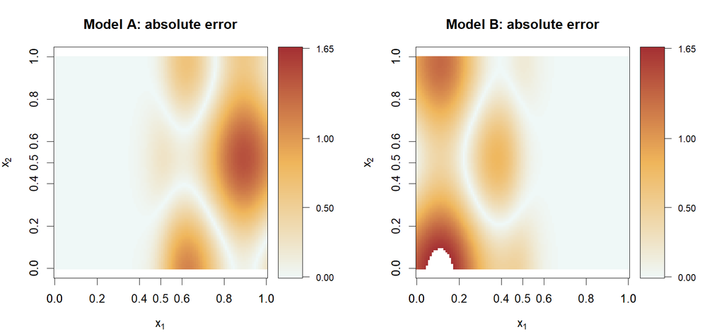

## Visual: a meta-learner learns where to trust A

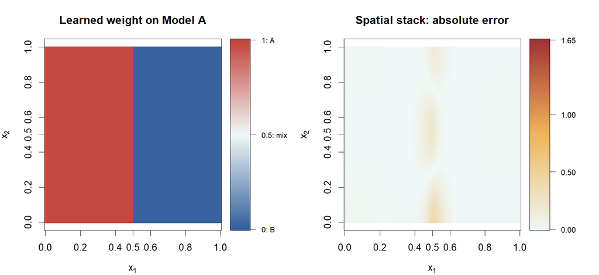

$$\hat y_{\mathrm{stack}}(x)=w(x_1)\hat y_A(x)+[1-w(x_1)]\hat y_B(x).$$

**Meta-inputs:** held-out base predictions **and** the feature $x_1$.

## Why a single blend can miss local strengths

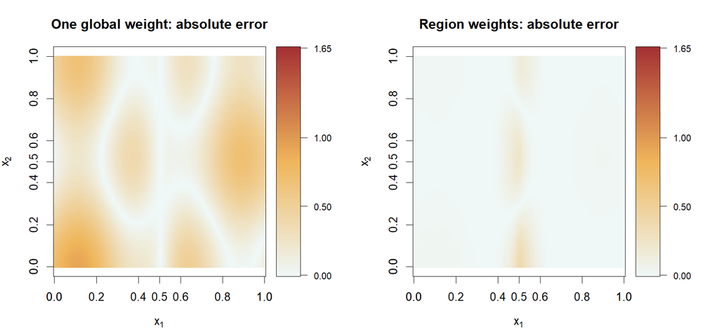

## Boosting and stacking solve different problems

| Question | Boosting | Stacking |
| --- | --- | --- |
| What does the next learner see? | Current ensemble’s loss-based correction targets | Base learners’ held-out predictions |
| What is the goal? | Improve one stagewise additive model | Learn how to combine trained models |
| Critical safeguard | Control complexity and stopping | Generate honest meta-features |

A boosted-tree model can itself be a base learner in a stack.

## Takeaways

- **Forest:** randomize training rows and predictor columns between trees and average to stabilize predictions.
- **Boosting:** add loss-guided tree corrections and learn sequentially.
- **Stacking:** train a meta-learner on out-of-fold base model predictions to learn where individuals perform well.